# DATA624 HW1

Can you spot any seasonality, cyclicity and trend? What do you learn about the series?

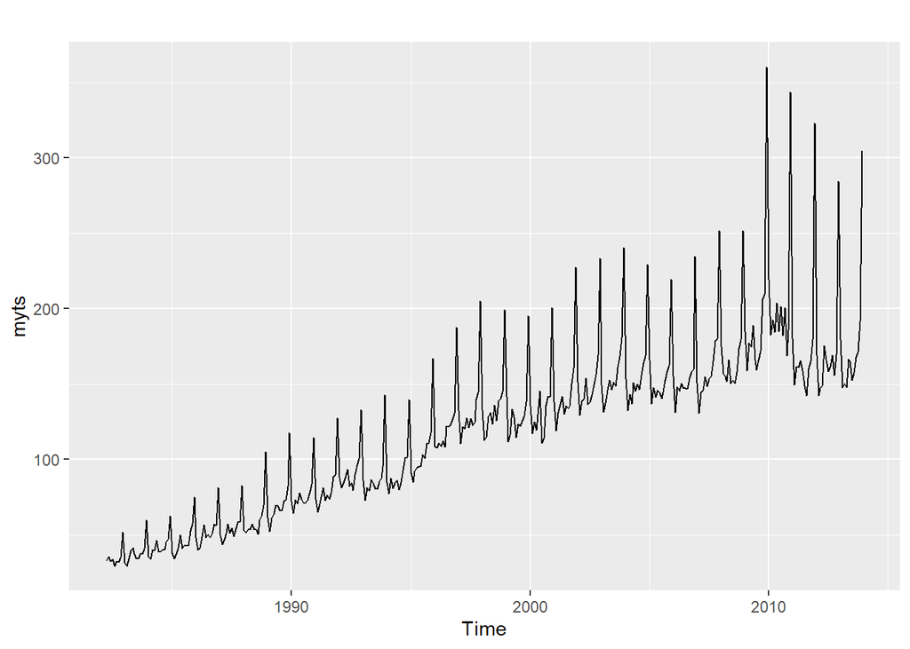

```r
autoplot(myts)
```

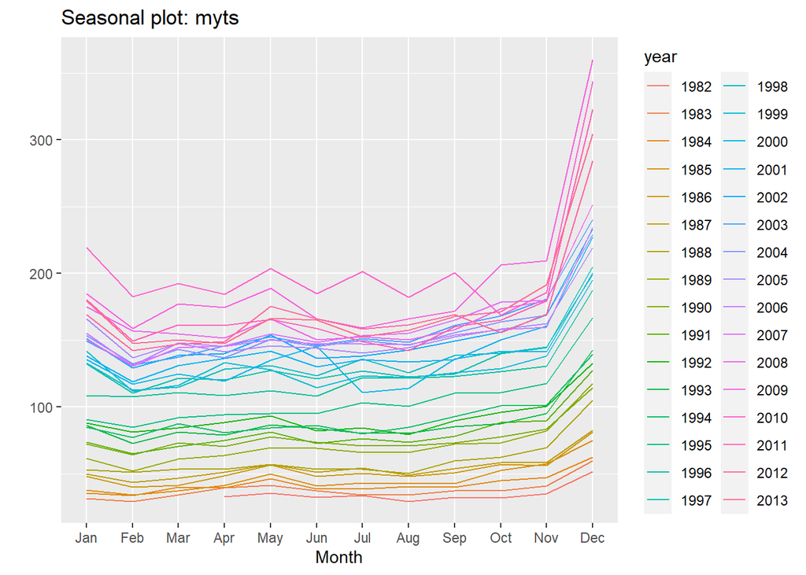

```r
ggseasonplot(myts)
```

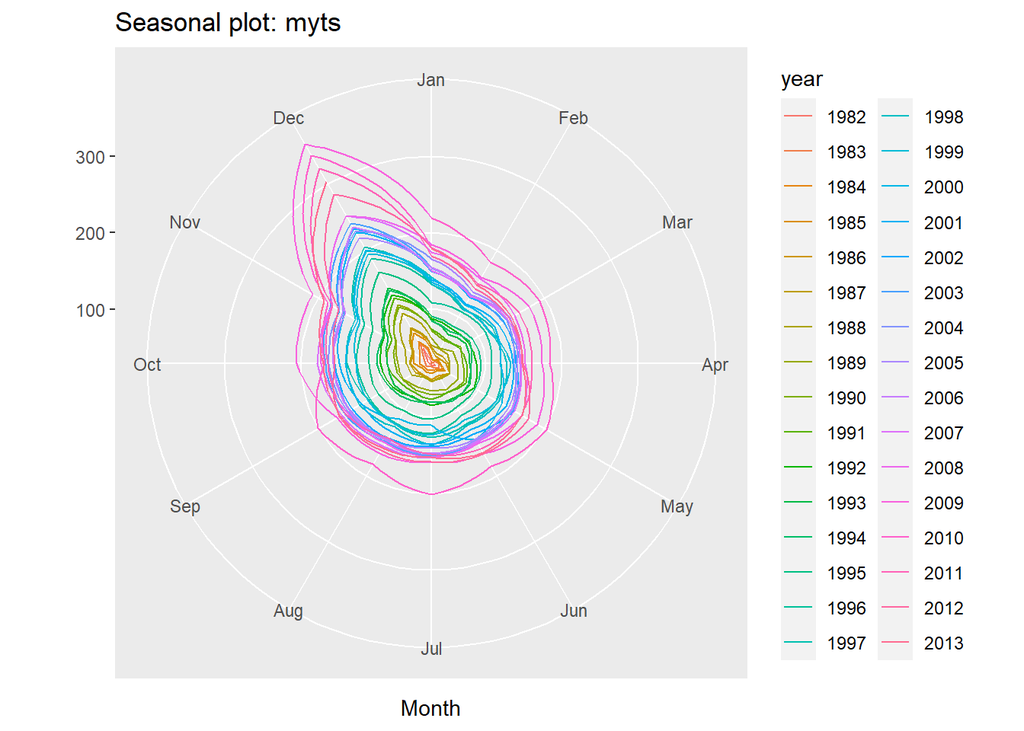

```r
ggseasonplot(myts, polar = TRUE)
```

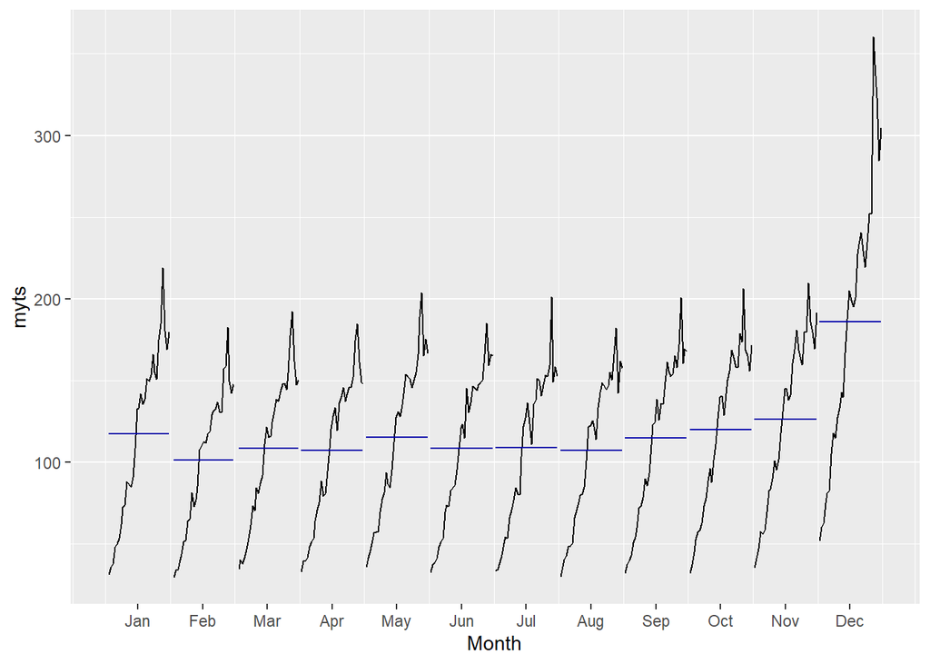

```r
ggsubseriesplot(myts)
```

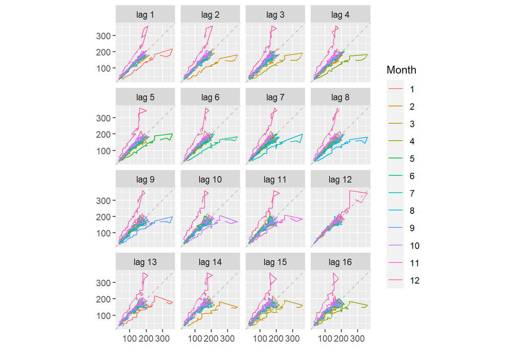

```r
gglagplot(myts)
```

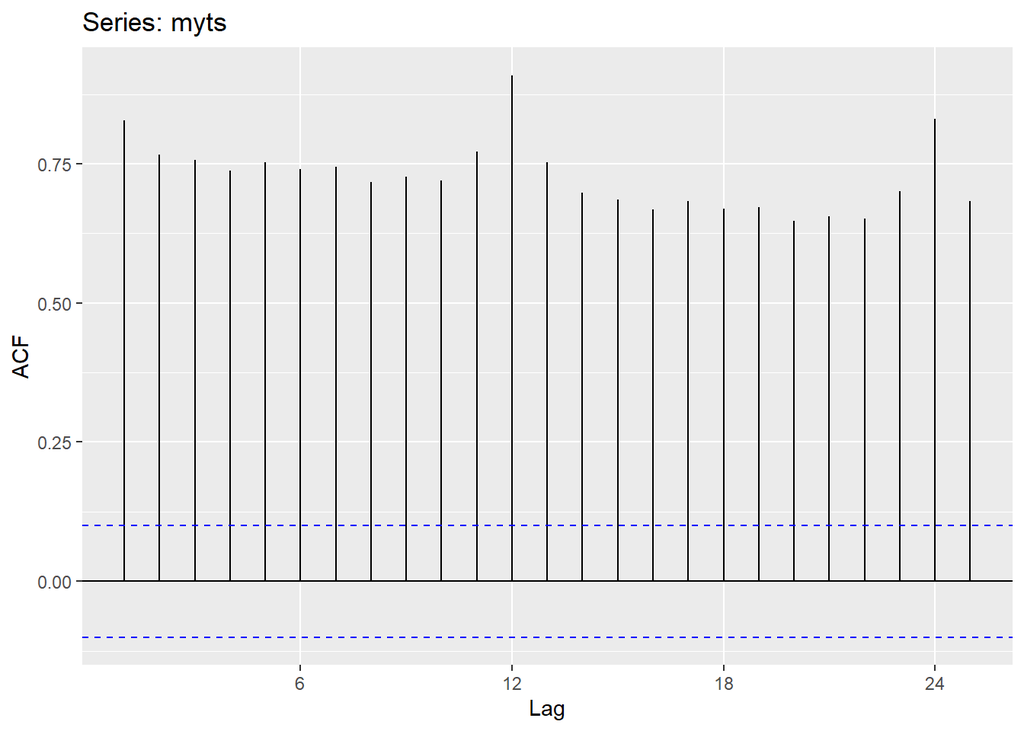

```r
ggAcf(myts)
```

Overall we can see that the trend over the years has been a rise in overall sales year-over-year.There have been a few sharp drops not fitting with the general trends most likely associated with extreme events/circumstances of some sort (e.g. Jun-Jul 2000, Sep-Oct 2012).

The lag plots all show positive correlations with plot 12 being particularly striking, highlighting the truly seasonal nature of the trends.

**Exercise 2.6:** Use the following graphics functions: `autoplot()`, `ggseasonplot()`, `ggsubseriesplot()`, `gglagplot()`, `ggAcf()` and explore features from the following time series: $hsales$, $usdeaths$, $bricksq$, $sunspotarea$, $gasoline$.

- Can you spot any seasonality, cyclicity and trend?
- What do you learn about the series?

```r
plots_t_ser <- function(ts, name){
  print(autoplot(ts) + ggtitle(name) +
    theme(plot.title = element_text(hjust = 0.5)))

  try(print(ggseasonplot(ts) + ggtitle(name) +
    theme(plot.title = element_text(hjust = 0.5))))

  try(print(ggseasonplot(ts, polar = TRUE) + ggtitle(name) +
    theme(plot.title = element_text(hjust = 0.5))))

  try(print(ggsubseriesplot(ts) + ggtitle(name) +
    theme(plot.title = element_text(hjust = 0.5))))

  print(gglagplot(ts) + ggtitle(name) +
    theme(plot.title = element_text(hjust = 0.5)))

  print(ggAcf(ts) + ggtitle(name) +
    theme(plot.title = element_text(hjust = 0.5)))
}
```

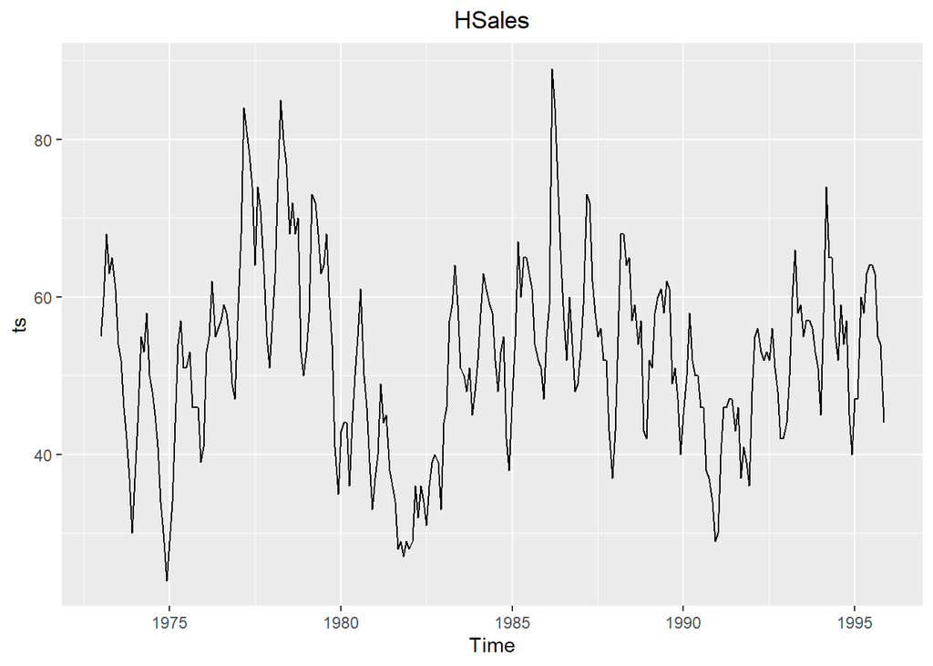

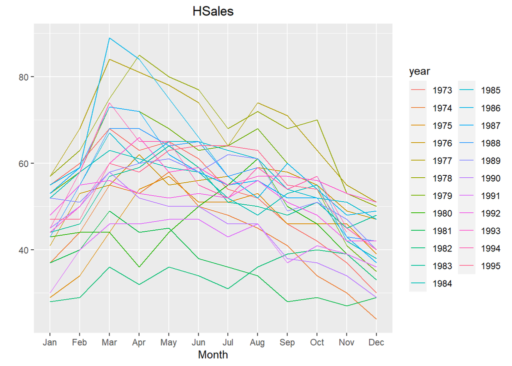

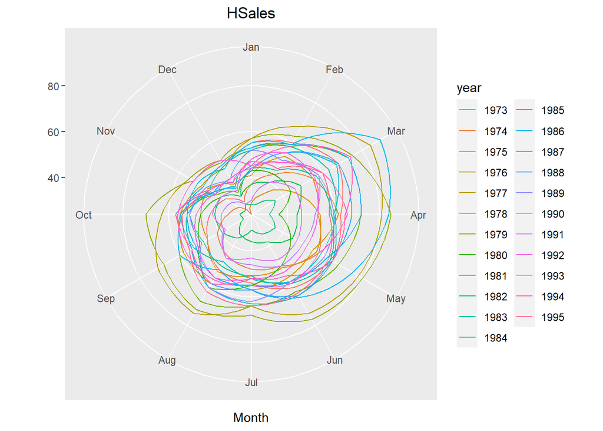

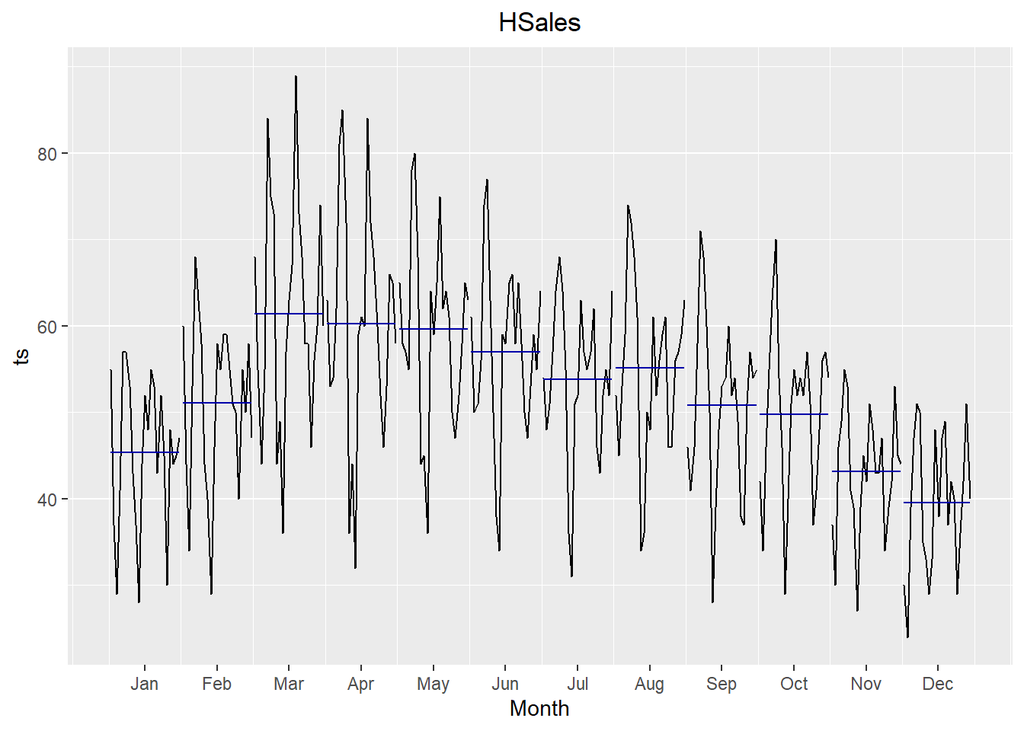

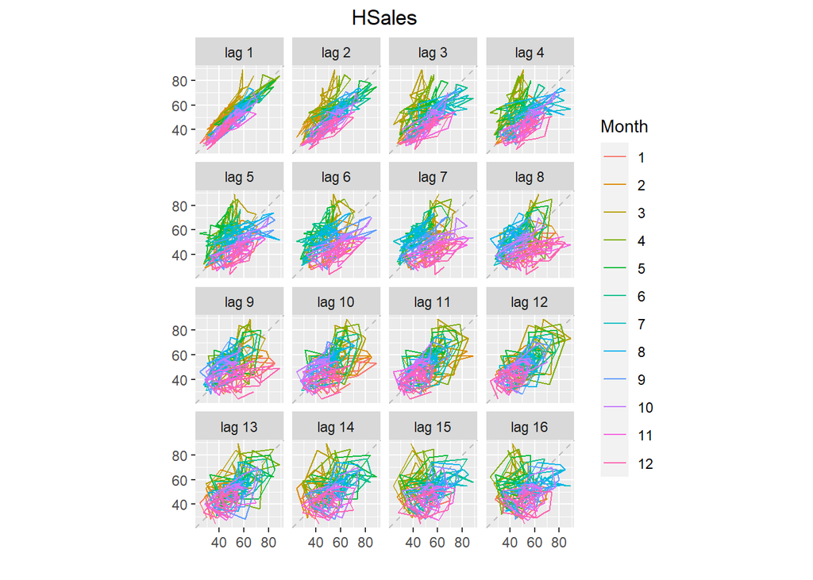

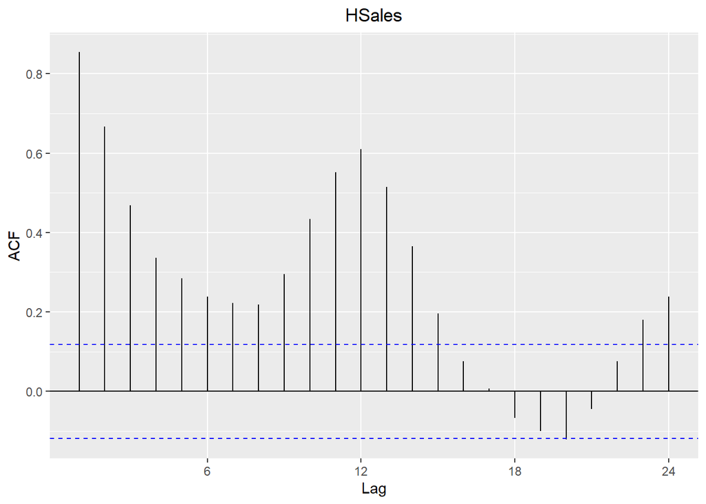

```r
plots_t_ser(hsales, 'HSales')
```

Hsales, the monthly sales data of new one-family homes in the US since 1973, shows a trendof peaking around April or March most years. The strongest lag indicators seem to be at 1 and 12, confirming the initial note of seasonality. The overall chart doesn’t point to an overall trend, with the data fluctuating steadily since 1973 and ending close to where it began. It’s interesting to note that the lag plots show negative coefficients for months 18-21 and low positives for 22-24. Perhaps this is indicative of a larger trend of fluctuating sales? Let’s look at a wider lag plot to see:

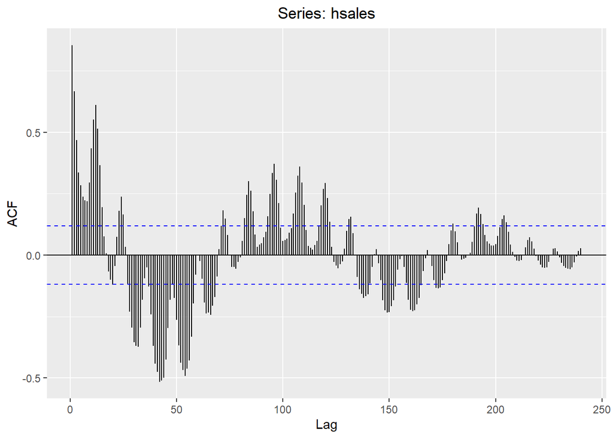

```r
ggAcf(hsales, lag = 240) +
    theme(plot.title = element_text(hjust = 0.5))
```

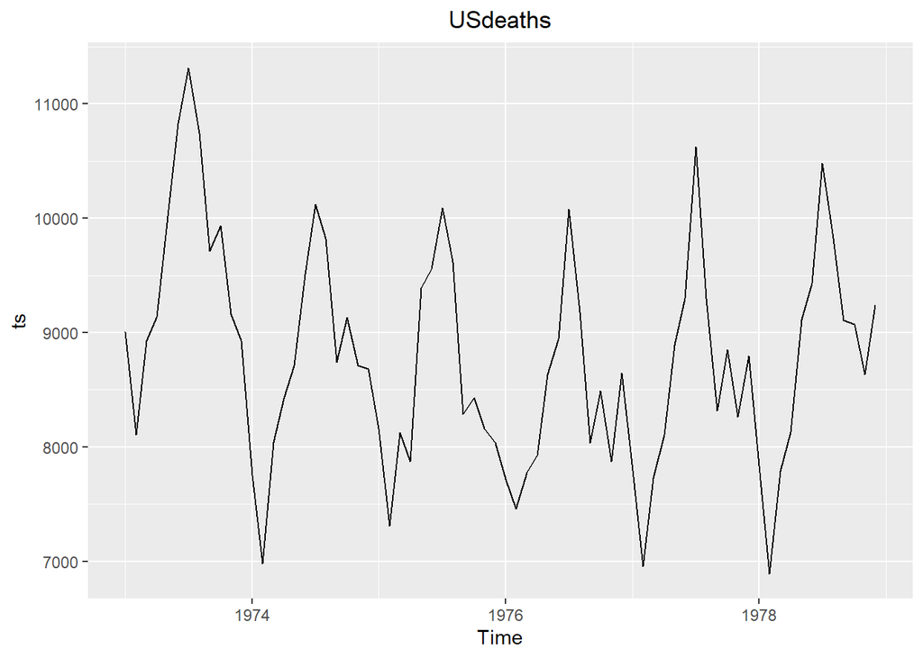

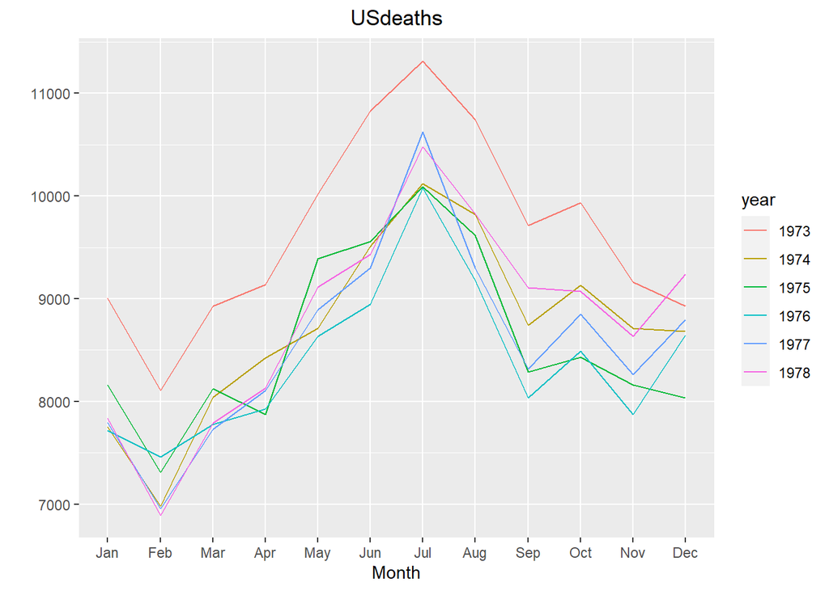

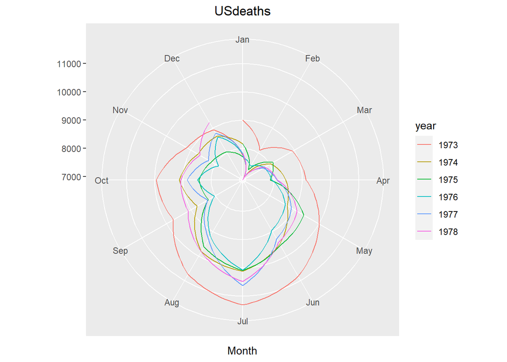

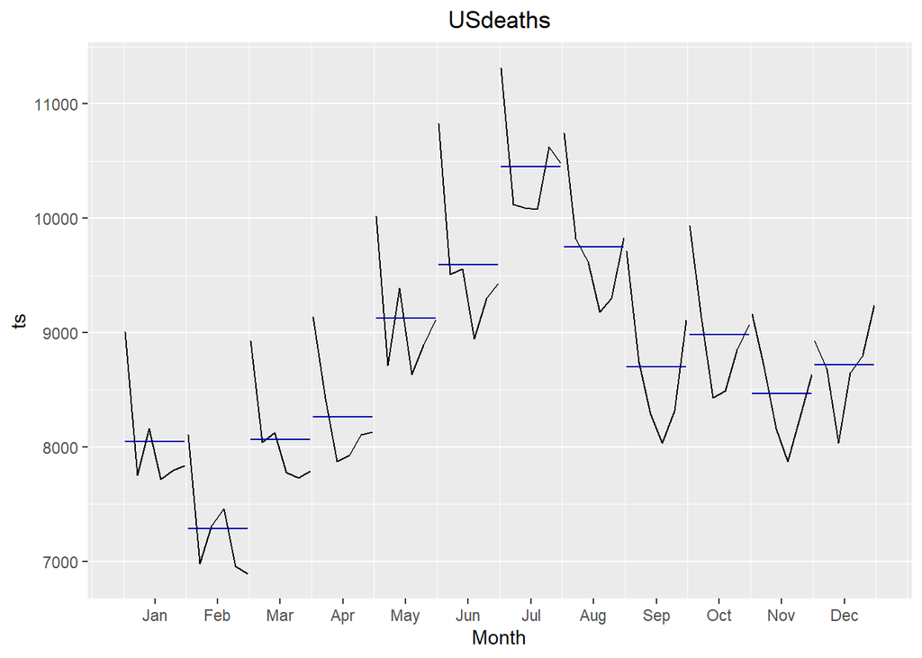

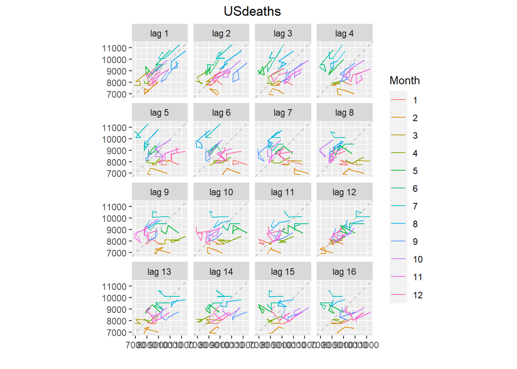

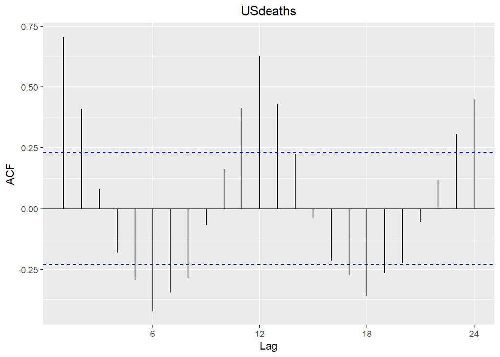

```r
plots_t_ser(usdeaths, 'USdeaths')
```

US deaths show a very strong seasonality, with deaths peaking in July and dipping in February every year from 1973 to 1978. The overall trend seems to be steady, though the peak in ’73 was the highest within the data, the rest of the values do not seem to exhibit too strong an either positive or negative trend.

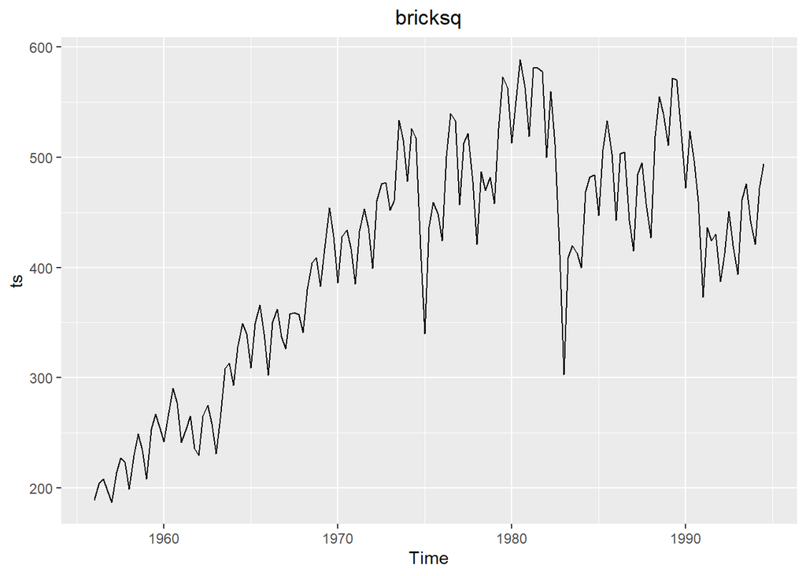

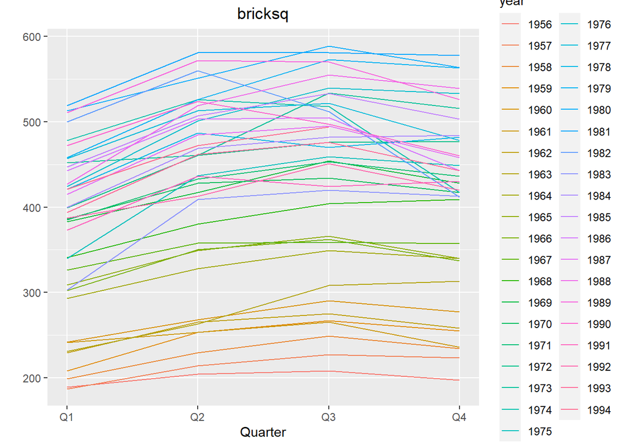

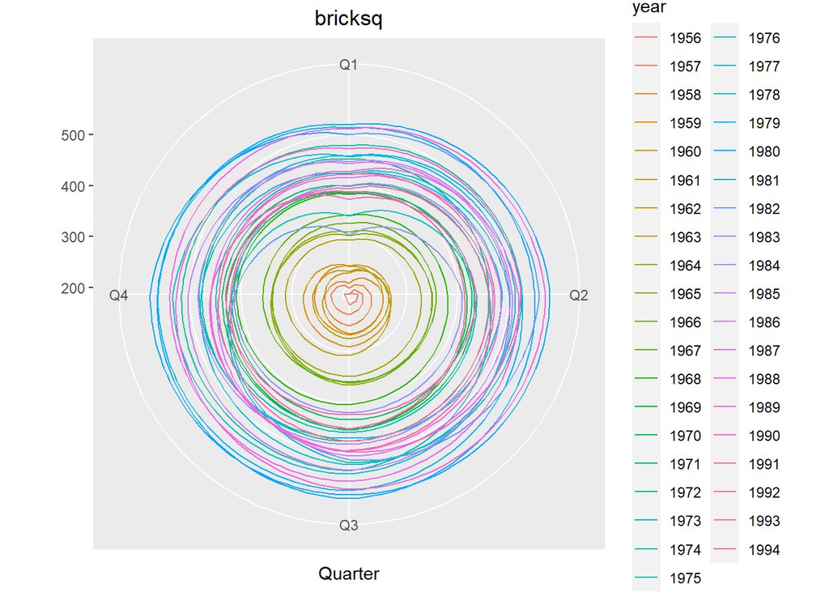

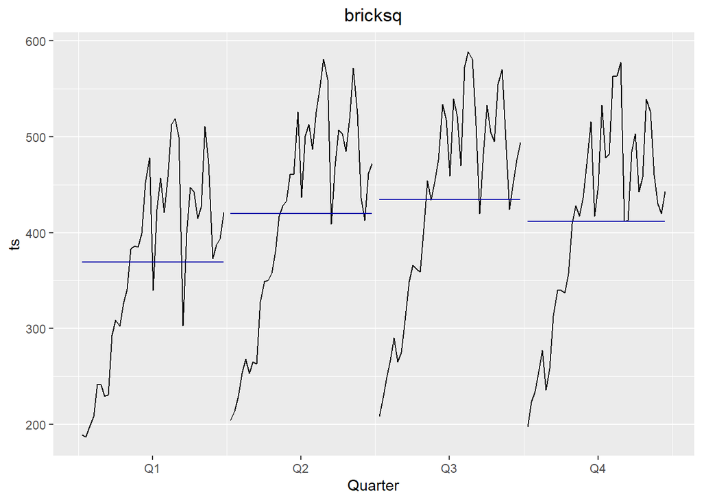

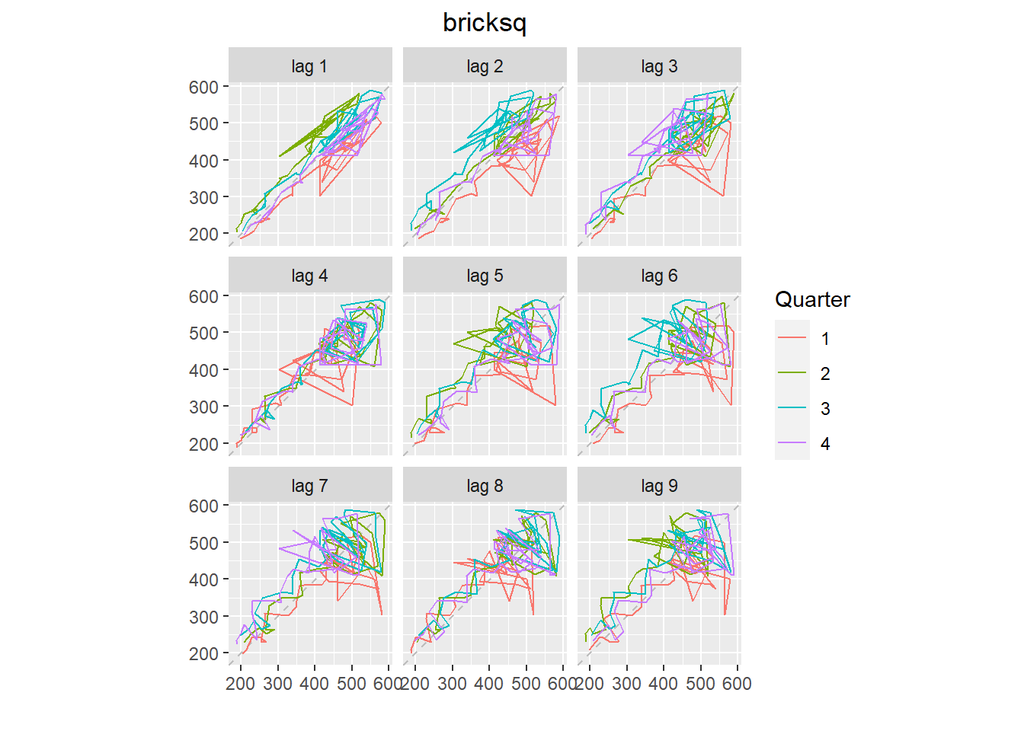

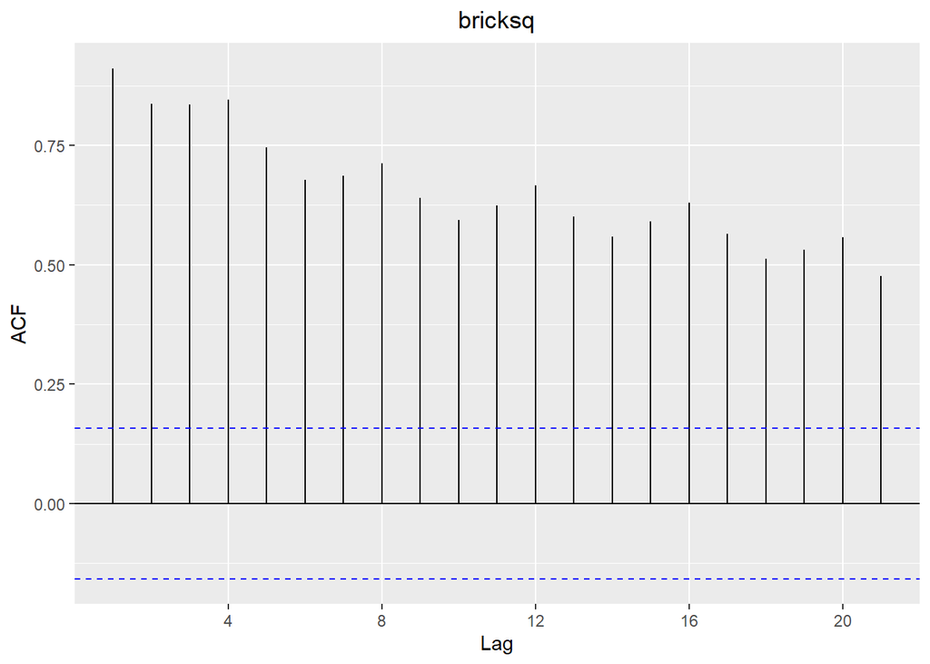

```r
plots_t_ser(bricksq, 'bricksq')
```

The trend immediately obvious from our first plot is a strong growth in the volume of Brick Production within Australia from 1956 to around 1975, at which point it seems to have stagnated somewhat. The seasonal plot indicates that production in Q1 tends to be the lowest within a year; the polar version is especially good at highlighting the similar values for Q2, Q3 and Q4 in each year, with the bottom half being nearly perfect circles every year.The lag plots suggest a positive overall trend, though this is undoubtedly strongly influenced by the rapid initial growth If we were to look at the data post-1975 I suspect the trend wouldn’t be nearly as positive, with the last couple of decades of data suggesting a stabilization of sorts.